# Setup: Introduction Module

## Cell type annotation from ADTs

We can leverage the ADTs as protein markers to identify likely cell types.

```r
# Again, what are the proteins?
rownames(altExp(norm_sce))
```

```
 [1] "CD3"   "CD4"   "CD8"   "CD11c" "CD14"  "CD16"  "CD19"  "CD56"  "CD45"  "IgG1"
```

Let’s explore via UMAPs, for example by coloring ADT counts:

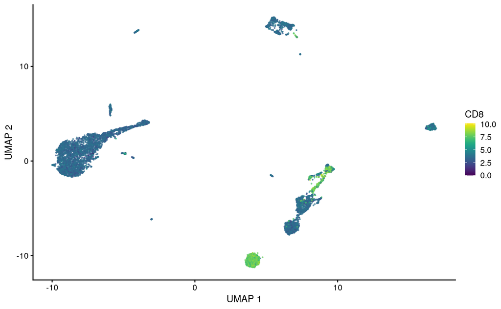

```r
# For example CD8
scater::plotReducedDim(norm_sce, "UMAP", colour_by = "CD8",
                       point_alpha = 0.6, point_size = 0.25)
```

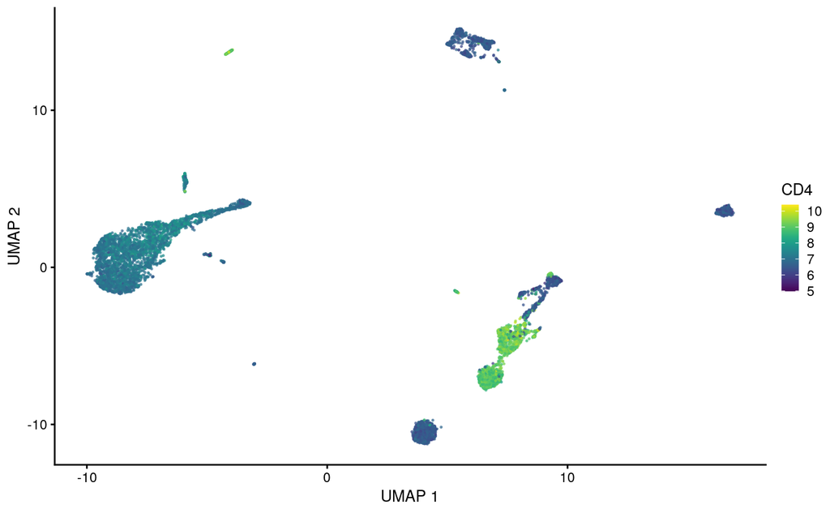

```r
# CD4, another T cell marker
scater::plotReducedDim(norm_sce, "UMAP", colour_by = "CD4",
                       point_alpha = 0.6, point_size = 0.25)
```

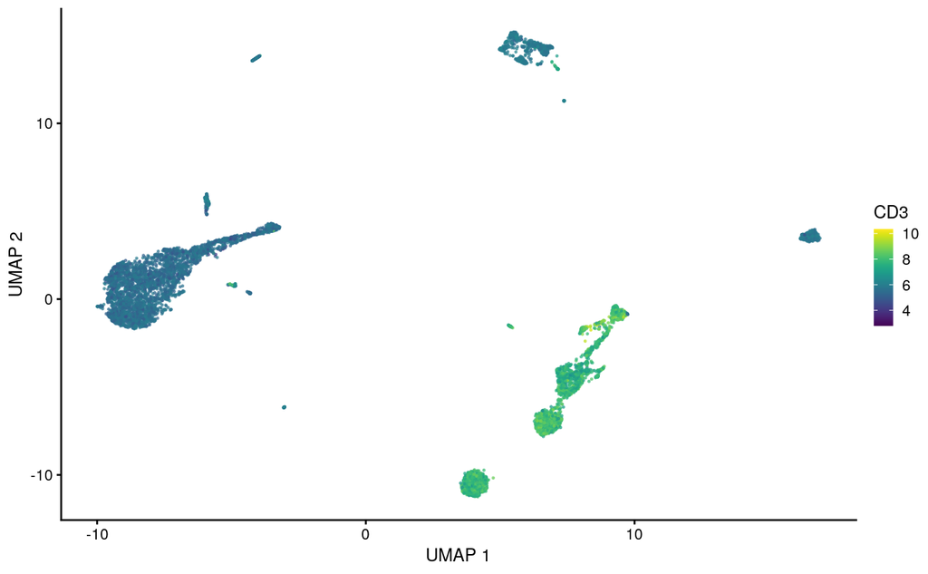

```r
# CD3 which lives on both CD4+ and CD8+ cells
# notice the greens coalescing!
scater::plotReducedDim(norm_sce, "UMAP", colour_by = "CD3",
                       point_alpha = 0.6, point_size = 0.25)
```

We can get a bit more sophisticated and look at the the most prevalent ADT across cells:

```r
# Which ADT is the most prevalent for each cell?
max_adt_indices <- apply(
  logcounts(altExp(norm_sce)),
  2,
  which.max
)
max_adt <- rownames(altExp(norm_sce))[max_adt_indices]

unique(max_adt)
```

```
[1] "CD4"   "CD14"  "CD19"  "CD3"   "CD11c" "CD16"  "CD56"  "CD8"
```

```r
# Add this into the main SCE experiment for UMAPing
norm_sce$max_adt <- max_adt
```

What are these proteins, and what cell types might they indicate? In the source quotes below, I have added the bold to the cell types.

- `CD3`
  - “CD3 (cluster of differentiation 3) is a protein complex and T cell co-receptor that is involved in activating both the **cytotoxic T cell (CD8+ naive T cells) and T helper cells (CD4+ naive T cells).** … This high specificity, combined with the presence of CD3 at all stages of T-cell development, makes it a useful immunohistochemical marker for T-cells in tissue sections.” source
- `CD4`
  - TCR co-receptor that we can probably assume is mostly on CD4+ T-cells
- `CD8`
  - TCR co-receptor that we can probably assume is mostly on CD8+ T-cells
- `CD11c`
  - “CD11c is a type I transmembrane protein that is expressed on **monocytes**, **granulocytes**, a subset of **B cells**, **dendritic cells**, and **macrophages** and may be demonstrated on B-cell chronic lymphocytic leukemia, marginal zone lymphomas, and hairy cell leukemia.” [source](https://www.sciencedirect.com/topics/neuroscience/cd11c)
- `CD14`
  - “CD14 is a glycolipid-anchored membrane glycoprotein expressed on cells of the myelomonocyte lineage including **monocytes**, **macrophages**, and some **granulocytes**.” [source](https://www.sciencedirect.com/topics/neuroscience/cd14)
- `CD16`
  - “CD16 is involved in antibody-dependent cell-mediated cytotoxicity and is expressed on large granular lymphocytes (LGLs) of both **NK- and T-cell types**.” [source](https://www.sciencedirect.com/topics/neuroscience/cd16)
- `CD19`
  - “CD19 is an IgSF surface glycoprotein of 95 kDa that is expressed from the earliest stages of **B cell** development until plasma cell terminal differentiation, when its expression is lost.” [source](https://www.sciencedirect.com/topics/neuroscience/cd19)
- `CD56`
  - “CD56 expression is also found in, among others, the hematopoietic system. Here, the expression of CD56 is mostly associated with, but not limited to, **natural killer cells**. CD56 has been detected on other lymphoid cells, including **gamma delta Τ cells and activated CD8+ T cells**, as well as on **dendritic cells**.” [source](https://en.wikipedia.org/wiki/Neural_cell_adhesion_molecule)

Let’s color cells by their most prevalent ADT:

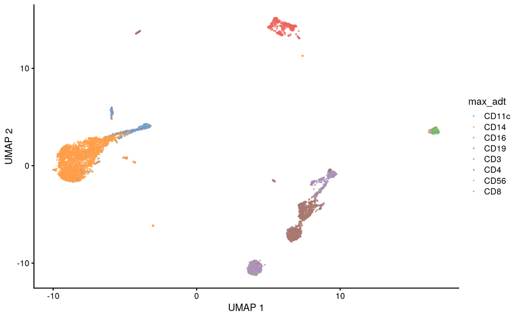

```r
scater::plotReducedDim(norm_sce, "UMAP", colour_by = "max_adt",
                       point_alpha = 0.6, point_size = 0.25)
```

## Cell type annotation from RNA

We can introduce annotation with `SingleR`, and it might be a good idea to show how the results are highly influenced by the reference. For now, I’m just using the `HumanPrimaryCellAtlasData` reference as a starting place. Note that all references here involve some caching, and we can expect some interactive prompting to go by for setting up these caches that we’ll have to walk everyone through. Specifically, the prompt is:

```markdown
/home/ccdl/stephanie/.cache/R/ExperimentHub
  does not exist, create directory? (yes/no):
```

Everyone needs to type **yes** since there is no default. If they hit enter, the prompt will keep prompting.

```r
ref_data <- celldex::HumanPrimaryCellAtlasData(ensembl = TRUE) # pick one for now to start
```

```
snapshotDate(): 2021-10-19
see ?celldex and browseVignettes('celldex') for documentation
loading from cache
see ?celldex and browseVignettes('celldex') for documentation
loading from cache
```

```r
yes
```

```
snapshotDate(): 2021-10-20
downloading 1 resources
retrieving 1 resource
```

```
loading from cache
require(“ensembldb”)
Warning: Unable to map 1470 of 19363 requested IDs.
```

```r
# Note that this variable has an uppercase R - watch for case typos!
singleR_predictions <- SingleR::SingleR(
  test = norm_sce,
  ref = ref_data,
  labels = ref_data$label.main, # "coarse-grained" labels
  # faster!
  BPPARAM = BiocParallel::MulticoreParam(4)
)
singleR_predictions
```

```
DataFrame with 7899 rows and 5 columns
                              scores first.labels     tuning.scores      labels pruned.labels
                            <matrix>  <character>       <DataFrame> <character>   <character>
1     0.165548:0.325545:0.295547:...      T_cells 0.418480:0.142392     T_cells       T_cells
2     0.167361:0.405463:0.436846:...     Monocyte 0.375351:0.138526    Monocyte      Monocyte
3     0.122209:0.329109:0.387877:...     Monocyte 0.427670:0.283137    Monocyte      Monocyte
4     0.145489:0.312505:0.287338:...      T_cells 0.488471:0.157934     T_cells       T_cells
5     0.135478:0.367149:0.302298:...       B_cell 0.345823:0.123575      B_cell        B_cell
...                              ...          ...               ...         ...           ...
7895 0.1255095:0.292856:0.265566:...      T_cells 0.334335:0.160698     T_cells       T_cells
7896 0.1263226:0.346052:0.314659:...      NK_cell 0.437051:0.317969     T_cells       T_cells
7897 0.0979106:0.328258:0.369513:...     Monocyte 0.399736:0.244188    Monocyte      Monocyte
7898 0.2041944:0.451736:0.478638:...     Monocyte 0.445823:0.123291    Monocyte      Monocyte
7899 0.1327571:0.366204:0.289806:...       B_cell 0.366204:0.313848      B_cell        B_cell
```

```r
# We can place these into the sce
norm_sce$celltype_predictions <- singleR_predictions$pruned.labels

# **heavily** biased towards monocytes and T-cells
celltype_counts <- singleR_predictions %>%
  as.data.frame() %>%
  dplyr::count(pruned.labels) %>%
  dplyr::arrange(desc(n))

celltype_counts
```

| pruned.labels | n |
| --- | --- |
| Monocyte | 3709 |
| T_cells | 2857 |
| B_cell | 726 |
| NK_cell | 363 |
| NA | 167 |
| Platelets | 35 |
| Pre-B_cell_CD34- | 13 |
| CMP | 11 |
| GMP | 10 |
| HSC_-G-CSF | 7 |

[output cut: 1 more lines]

```r
NA
```

Visualize the predictions in a couple ways:

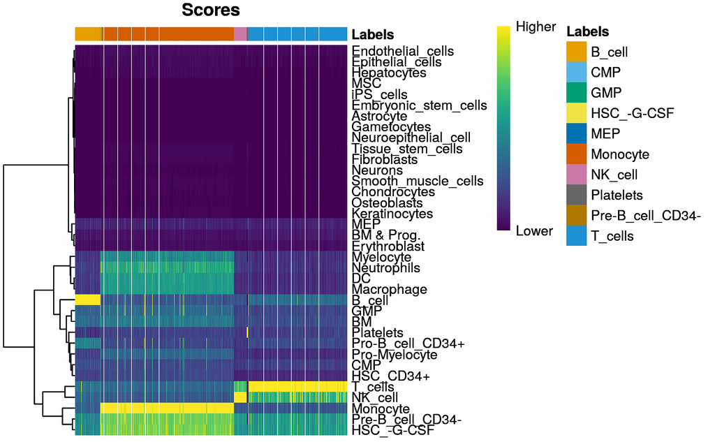

```r
SingleR::plotScoreHeatmap(singleR_predictions)
```

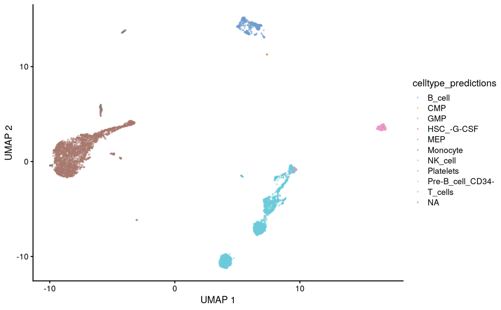

```r
# Not too shabby!
scater::plotReducedDim(norm_sce, "UMAP", colour_by = "celltype_predictions",
                       point_alpha = 0.4, point_size = 0.25)
```

```r
# The top 5 cell types account for over 98% of the cells!
celltype_counts %>%
  dplyr::slice(1:5) %>%
  dplyr::summarize(sum(n) / sum(celltype_counts$n))
```

| sum(n)/sum(celltype_counts$n) |
| --- |
| 0.9902519 |

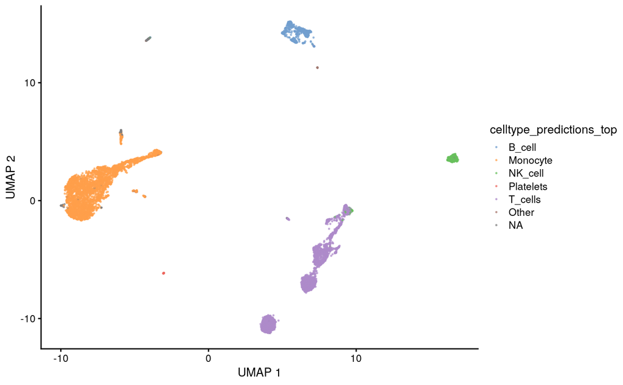

```r
top_celltypes <- as.character(celltype_counts$celltype[1:5])

# Recode a new celltype vector with top 5 separated from "other" using some forcats magic
norm_sce$celltype_predictions_top <- forcats::fct_lump_n(norm_sce$celltype_predictions, 5)

scater::plotReducedDim(norm_sce, "UMAP", colour_by = "celltype_predictions_top",
                       point_alpha = 0.6, point_size = 0.25)
```